# Replication Extension with Twitter Data: Using Doc2Vec

## STEP 0: Environment Setup

## STEP 1: Define Python preprocessing functions

```python
import pandas as pd
import numpy as np
import re
import os
import emoji
import string
from gensim.models.doc2vec import TaggedDocument, Doc2Vec
from gensim.utils import simple_preprocess
import nltk
nltk.download("stopwords", quiet=True)
```

```
## True
```

```python
from nltk.corpus import stopwords

# Create necessary directories
os.makedirs("data", exist_ok=True)
os.makedirs("models", exist_ok=True)
```

## STEP 2: Define Python functions for processing tweets

```python
# Function to remove emojis
def remove_emoji(text):
    return emoji.replace_emoji(text, replace="")

# Function to clean text more thoroughly
def clean_text(text):
    # Remove URLs
    text = re.sub(r"http\S+|www\S+", "", text)
    # Remove @handles
    text = re.sub(r"@\w+", "", text)
    # Remove emojis
    text = remove_emoji(text)
    # Convert to lowercase
    text = text.lower()
    # Remove punctuation
    text = re.sub(r"[^\w\s]", " ", text)
    # Remove digits
    text = re.sub(r"\d+", "", text)
    # Remove single letters
    text = re.sub(r"\b[a-zA-Z]\b", "", text)
    # Remove extra whitespace
    text = re.sub(r"\s+", " ", text)
    return text.strip()

# Define function to load and preprocess tweets
def load_and_preprocess_tweets(csv_path):
    """
    Reads the tweet CSV, drops retweets & missing text,
    groups by user, concatenates all tweets into one doc per user.
    Returns a DataFrame with columns: [author, text].
    """
    df = pd.read_csv(csv_path)
    # drop retweets
    df = df[df["retweet_author"].isnull()]
    # drop missing text/author
    df = df.dropna(subset=["text", "author"])
    # Add party info for later
    df = df.rename(columns={"Party": "party"})

    # Clean tweets
    df["text_clean"] = df["text"].apply(clean_text)

    # group by author
    user_docs = df.groupby("author").agg({
        "text_clean": " ".join,
        "party": lambda x: x.iloc[0]  # Take the first party label (should be consistent)
    }).reset_index()

    return user_docs
```

## STEP 3: Define Python functions for Doc2Vec modeling

```python
# Function to tokenize with expanded stopwords
def tokenize_documents(user_docs):
    """
    Tokenizes each user doc with more comprehensive stopword removal.
    Returns a list of TaggedDocument objects.
    """
    # Expanded stopwords - NLTK + custom
    stop_words = set(stopwords.words("english"))
    # Add custom stopwords
    custom_stops = {"amp", "rt", "via", "im", "thats", "id", "us", "ive", "dont",
                   "cant", "youre", "youve", "isnt", "wasnt", "didnt", "wont",
                   "couldnt", "shouldnt", "wouldnt", "arent"}
    stop_words.update(custom_stops)

    # Add single letters (though already removed in cleaning)
    stop_words.update(set(string.ascii_lowercase))

    documents = []
    for row in user_docs.itertuples():
        user = row.author
        party = row.party

        # Use simple_preprocess to remove punctuation, short tokens, etc.
        tokens = simple_preprocess(row.text_clean, deacc=True, min_len=3)

        # Remove stopwords
        tokens = [word for word in tokens if word not in stop_words]

        if tokens:  # Only add if there are tokens left
            documents.append(TaggedDocument(words=tokens, tags=[user, party]))

    return documents

# Function to train PV-DM model (similar to the original paper)
def train_pvdm_model(tagged_docs, vector_size=200, window=20, min_count=5, epochs=20):
    """
    Trains a Doc2Vec model with PV-DM (dm=1).
    Uses parameters similar to the original paper.
    """
    model = Doc2Vec(
        documents=tagged_docs,
        vector_size=vector_size,
        window=window,
        min_count=min_count,
        workers=4,
        dm=1,            # PV-DM approach (as used in original paper)
        dm_concat=False, # average context vectors
        epochs=epochs
    )
    return model
```

## STEP 4: Load and process tweets

```python
# Load the tweets CSV
csv_path = "tweets_congress.csv"
user_docs = load_and_preprocess_tweets(csv_path)

# Print some stats about the data (optional)
print(f"Loaded data for {len(user_docs)} unique users")
```

```
## Loaded data for 425 unique users
```

```python
print(f"Party distribution: {user_docs['party'].value_counts().to_dict()}")
```

```
## Party distribution: {'D': 232, 'R': 191, 'I': 2}
```

```python
# Sample of processed text (optional)
print("\nSample of processed text:")
```

```
##
## Sample of processed text:
```

```python
print(user_docs.iloc[0]['text_clean'][:200] + "...")
```

```
## it is my team privilege to help our constituents navigate issues with federal agencies and listen to their concer am proud to have sponsored this amendment which was signed into law as part of the fy ...
```

## STEP 5: Create document tags and train Doc2Vec model

```python
# Tokenize and tag
tagged_docs = tokenize_documents(user_docs)

# Print sample to verify (optional)
# print(f"Sample document: {tagged_docs[0]}")
print(f"Total documents: {len(tagged_docs)}")
```

```
## Total documents: 425
```

```python
# Train PV-DM model
model = train_pvdm_model(tagged_docs)

# Save model
model.save("models/twitter_users_pvdm.model")
```

## STEP 6: Extract user embeddings

```python
# Create mapping of users to parties
user_party_map = user_docs[["author", "party"]].set_index("author").to_dict()["party"]

# Extract user embeddings
user_ids = []
user_parties = []
user_vecs = []

# Handle tags correctly because they can be tuples
for tag in model.docvecs.doctags.keys():
    # If it's a tuple, get the first element (the user ID)
    if isinstance(tag, tuple):
        user_id = tag[0]
    else:
        user_id = tag

    # Skip if we don't have party info
    if user_id not in user_party_map:
        continue

    user_ids.append(user_id)
    user_parties.append(user_party_map[user_id])
    user_vecs.append(model.docvecs[tag])

# Create dataframe with embeddings
df_user_vectors = pd.DataFrame(user_vecs)
df_user_vectors["user"] = user_ids
df_user_vectors["party"] = user_parties

# Save to CSV for R analysis
df_user_vectors.to_csv("data/twitter_user_vectors_pvdm.csv", index=False)
```

## STEP 7: PCA and visualization in R

```r
# Load the user-level vectors
user_vecs <- read_csv("data/twitter_user_vectors_pvdm.csv")
# Make sure party is treated as a factor
user_vecs$party <- factor(user_vecs$party, levels = c("D", "R"))

# Extract user and party info
users <- user_vecs$user
parties <- user_vecs$party

# Check data dimensions
cat("Loaded embeddings for", nrow(user_vecs), "users\n")
```

```
## Loaded embeddings for 425 users
```

```r
cat("Party distribution:\n")
```

```
## Party distribution:
```

```r
print(table(user_vecs$party))
```

```
##
##   D   R
## 232 191
```

```r
# Remove non-numeric columns for PCA
mat <- user_vecs %>%
  select(-user, -party) %>%
  as.matrix()

# Run PCA
pca <- prcomp(mat, scale. = TRUE)

# Create dataframe for plotting
pca_scores <- as.data.frame(pca$x) %>%
  mutate(
    user = users,
    party = parties
  )

# Extract PC1 loadings and convert to a unit vector
pc1 <- pca$rotation[, 1]
pc1 <- pc1 / sqrt(sum(pc1^2))

# Save PC1 to a file that Python can read
write.csv(pc1, "data/PC1_vector.csv")

# Extract PC2 loadings and convert to a unit vector
pc2 <- pca$rotation[, 2]
pc2 <- pc2 / sqrt(sum(pc2^2))

# Save PC2 to a file that Python can read
write.csv(pc2, "data/PC2_vector.csv")
```

## STEP 8: Visualizing PCA Results

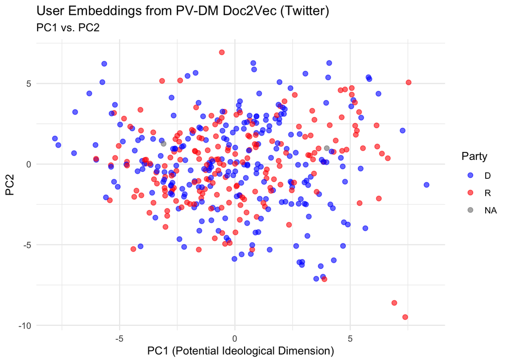

```r
# PC1 vs PC2 plot
pc1_pc2_plot <- ggplot(pca_scores, aes(x = PC1, y = PC2, color = party)) +
  geom_point(alpha = 0.6, size = 2) +
  scale_color_manual(values = c("D" = "blue", "R" = "red")) +
  theme_minimal() +
  labs(
    title = "User Embeddings from PV-DM Doc2Vec (Twitter)",
    subtitle = "PC1 vs. PC2",
    x = "PC1 (Potential Ideological Dimension)",
    y = "PC2",
    color = "Party"
  )

# Display the plot
print(pc1_pc2_plot)
```

```r
# Calculate variance explained
var_explained <- summary(pca)$importance[2, 1:5] * 100

# Print variance explained
cat("Variance explained by first 5 components:\n")
```

```
## Variance explained by first 5 components:
```

```r
for (i in 1:5) {
  cat(sprintf("PC%d: %.2f%%\n", i, var_explained[i]))
}
```

```
## PC1: 4.67%
## PC2: 3.74%
## PC3: 3.29%
## PC4: 3.07%
## PC5: 2.49%
```

#### Comments:

Similar to our earlier observations, there’s **no clear separation** between Democrats (blue) and Republicans (red) along the PC1 axis. *This contrasts with the clear partisan divisions seen in parliamentary speeches in the original paper.*

## STEP 9: Examine Most Extreme Users on PC1

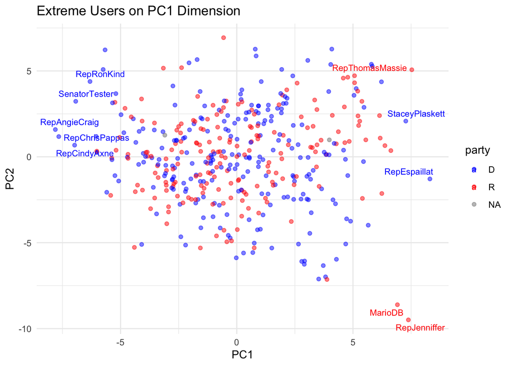

```r
# Identify extreme users on PC1
top_users <- pca_scores %>%
  arrange(desc(PC1)) %>%
  slice_head(n = 5)

bottom_users <- pca_scores %>%
  arrange(PC1) %>%
  slice_head(n = 5)

extreme_users <- bind_rows(top_users, bottom_users)

# Plot with labeled extremes
labeled_plot <- ggplot(pca_scores, aes(x = PC1, y = PC2, color = party)) +
  geom_point(alpha = 0.5) +
  geom_text_repel(
    data = extreme_users,
    aes(label = user),
    size = 3,
    max.overlaps = 15
  ) +
  scale_color_manual(values = c("D" = "blue", "R" = "red")) +
  theme_minimal() +
  labs(title = "Extreme Users on PC1 Dimension")

# Display the labeled plot
print(labeled_plot)
```

## STEP 10: Examine Most Extreme Words on PC1

```python
# Load the model
from gensim.models import Doc2Vec
model = Doc2Vec.load("models/twitter_users_pvdm.model")

# Load PC1 vector from R
pc1_df = pd.read_csv("data/PC1_vector.csv")
pc1 = pc1_df.iloc[:, 1].values  # take the values column

# Normalize PC1
pc1 = pc1 / np.linalg.norm(pc1)

# Project words onto PC1
word_projections = {}
for word in model.wv.vocab:
    vec = model.wv[word]
    # Skip rare words with strange vectors
    if np.any(np.isnan(vec)) or np.all(vec == 0):
        continue

    # Normalize word vector
    vec_norm = np.linalg.norm(vec)
    if vec_norm > 0:  # Avoid division by zero
        norm_vec = vec / vec_norm
        # Calculate projection (dot product)
        score = np.dot(pc1, norm_vec)
        word_projections[word] = score

# Sort words by projection score
sorted_words = sorted(word_projections.items(), key=lambda x: x[1])

# Get extreme words on both ends
neg_extreme = sorted_words[:20]
pos_extreme = sorted_words[-20:][::-1]  # reverse to get highest first

# Print extreme words
print("Extreme negative end of PC1:")
```

```
## Extreme negative end of PC1:
```

```python
for word, score in neg_extreme[:10]:  # Just show 10 for brevity
    print(f"{word:<20s} {score:.4f}")
```

```
## locks                -0.3434
## michiganders         -0.3286
## granite              -0.3204
## kansans              -0.3159
## flexibilities        -0.3121
## haulers              -0.3110
## iowans               -0.3072
## livestock            -0.2943
## blending             -0.2908
## northdakota          -0.2821
```

```python
print("\nExtreme positive end of PC1:")
```

```
##
## Extreme positive end of PC1:
```

```python
for word, score in pos_extreme[:10]:  # Just show 10 for brevity
    print(f"{word:<20s} {score:.4f}")
```

```
## espaillat            0.5468
## personas             0.5368
## presidente           0.5302
## puedes               0.5096
## esta                 0.4920
## condeno              0.4837
## una                  0.4819
## sus                  0.4814
## inscripcion          0.4778
## grupos               0.4760
```

```python
# Save as CSV for R plotting
extreme_words_df = pd.DataFrame(
    neg_extreme + pos_extreme,
    columns=["word", "score"]
)
extreme_words_df["end"] = ["negative"] * 20 + ["positive"] * 20
extreme_words_df.to_csv("data/extreme_words_pc1.csv", index=False)
```

### Analysis:

- These terms strongly point to *rural, agricultural, and resource-based* economies and constituencies.
- The emphasis on *state identities* (“michiganders,” “kansans”) seem to suggests a focus on local identity and regional concerns.

- These are primarily *Spanish language terms*, indicating communication targeting Spanish-speaking constituents.
- The presence of “espaillat” likely refers to Rep. Adriano Espaillat, the first *Dominican-American member* of Congress.

### Comment:

Compared to the results from GloVe, using a similar method as the paper has allowed us to effectively captured the regional and demographic dimensions of congressional Twitter communication.

This shows that the paper’s methodology can be applied in a different dataset. In this case, it demonstrates *how representatives tailor their messaging* to their specific constituencies *rather than adhering strictly to party-line language.*

### Visualize Extreme Words on PC1

```r
# Load extreme words
extreme_words <- read_csv("data/extreme_words_pc1.csv")
```

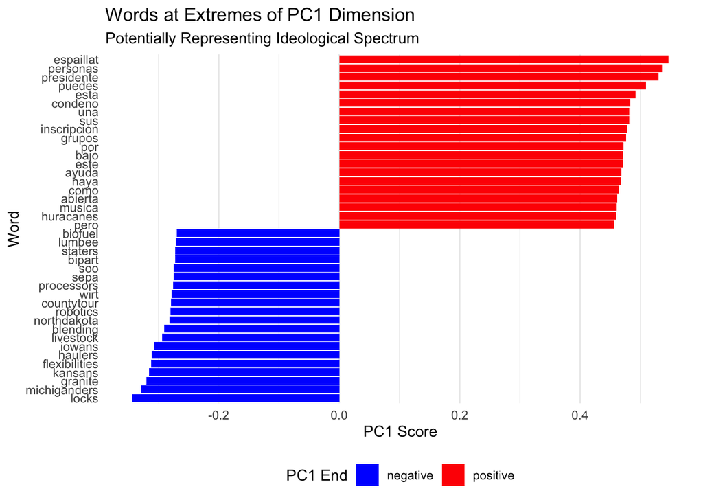

```r
# Create a visualization of extreme words
word_plot <- ggplot(extreme_words, aes(x = score, y = reorder(word, score), fill = end)) +
  geom_col() +
  scale_fill_manual(values = c("negative" = "blue", "positive" = "red")) +
  labs(
    title = "Words at Extremes of PC1 Dimension",
    subtitle = "Potentially Representing Ideological Spectrum",
    x = "PC1 Score",
    y = "Word",
    fill = "PC1 End"
  ) +
  theme_minimal() +
  theme(
    legend.position = "bottom",
    panel.grid.major.y = element_blank()
  )

# Display the plot
print(word_plot)
```

## STEP 11: Examining Extreme Words on PC2

```python
# Load the model
from gensim.models import Doc2Vec
model = Doc2Vec.load("models/twitter_users_pvdm.model")

# Load PC2 vector
pc2_df = pd.read_csv("data/PC2_vector.csv")
pc2 = pc2_df.iloc[:, 1].values  # take the values column

# Normalize PC2
pc2 = pc2 / np.linalg.norm(pc2)

# Project words onto PC2
word_projections = {}
for word in model.wv.vocab:
    vec = model.wv[word]
    # Skip rare words with strange vectors
    if np.any(np.isnan(vec)) or np.all(vec == 0):
        continue

    # Normalize word vector
    vec_norm = np.linalg.norm(vec)
    if vec_norm > 0:  # Avoid division by zero
        norm_vec = vec / vec_norm
        # Calculate projection (dot product)
        score = np.dot(pc2, norm_vec)
        word_projections[word] = score

# Sort words by projection score
sorted_words = sorted(word_projections.items(), key=lambda x: x[1])

# Get extreme words on both ends
neg_extreme = sorted_words[:20]
pos_extreme = sorted_words[-20:][::-1]  # reverse to get highest first

# Print extreme words
print("Extreme negative end of PC2:")
```

```
## Extreme negative end of PC2:
```

```python
for word, score in neg_extreme:
    print(f"{word:<20s} {score:.4f}")
```

```
## conocer              -0.5182
## hicimos              -0.4698
## lucha                -0.4615
## importancia          -0.4588
## proteger             -0.4524
## pais                 -0.4493
## muerte               -0.4457
## hagamos              -0.4450
## nuestras             -0.4416
## mientras             -0.4361
## hablamos             -0.4357
## contra               -0.4302
## muy                  -0.4281
## tantos               -0.4281
## periodo              -0.4253
## junto                -0.4217
## punto                -0.4197
## bajo                 -0.4197
## hispana              -0.4180
## quienes              -0.4156
```

```python
print("\nExtreme positive end of PC2:")
```

```
##
## Extreme positive end of PC2:
```

```python
for word, score in pos_extreme:
    print(f"{word:<20s} {score:.4f}")
```

```
## accuse               0.4663
## stuff                0.4380
## probably             0.4050
## sore                 0.3980
## kellyanne            0.3961
## guy                  0.3879
## dare                 0.3861
## pulling              0.3561
## fine                 0.3539
## assume               0.3504
## might                0.3464
## soy                  0.3438
## parroting            0.3435
## garbage              0.3434
## printed              0.3412
## thinks               0.3389
## slogans              0.3382
## etc                  0.3375
## blaming              0.3359
## flat                 0.3327
```

```python
# Save as CSV for R plotting
extreme_words_df = pd.DataFrame(
    neg_extreme + pos_extreme,
    columns=["word", "score"]
)
extreme_words_df["end"] = ["negative"] * 20 + ["positive"] * 20
extreme_words_df.to_csv("data/extreme_words_pc2.csv", index=False)
```

```r
# Load extreme words for PC2
extreme_words_pc2 <- read_csv("data/extreme_words_pc2.csv")
```

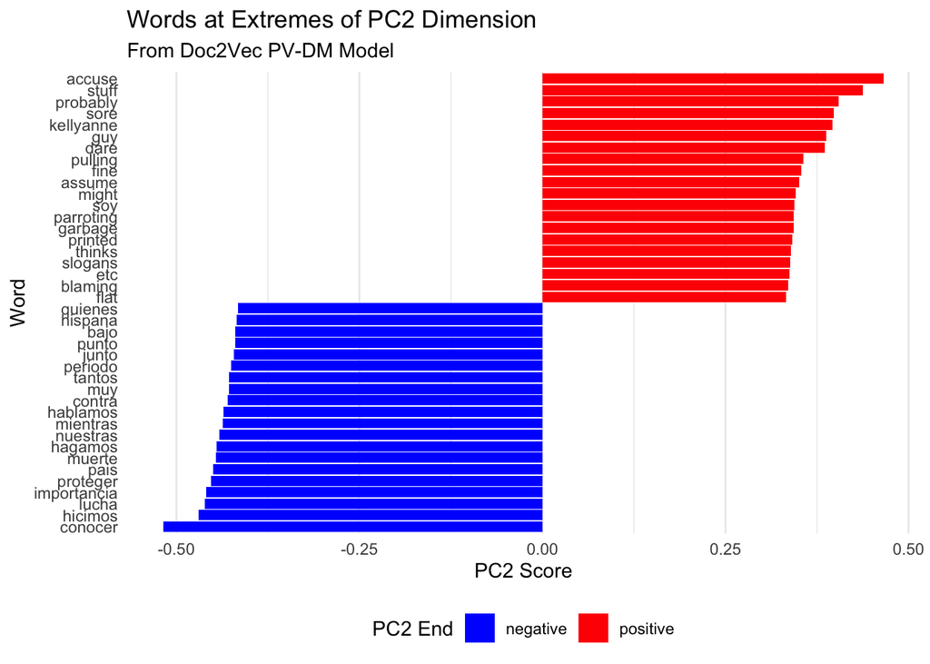

```r
# Create a visualization of extreme words for PC2
word_plot_pc2 <- ggplot(extreme_words_pc2, aes(x = score, y = reorder(word, score), fill = end)) +
  geom_col() +
  scale_fill_manual(values = c("negative" = "blue", "positive" = "red")) +
  labs(
    title = "Words at Extremes of PC2 Dimension",
    subtitle = "From Doc2Vec PV-DM Model",
    x = "PC2 Score",
    y = "Word",
    fill = "PC2 End"
  ) +
  theme_minimal() +
  theme(
    legend.position = "bottom",
    panel.grid.major.y = element_blank()
  )

# Display the plot
print(word_plot_pc2)
```

## Analysis for PC2

#### **Negative End of PC2**

Words at the negative extreme are predominantly *Spanish language terms.* This suggests PC2’s negative end captures **communication targeting Hispanic constituencies**.

#### **Positive End of PC2**

This indicates PC2’s positive end represents a more *confrontational, informal, and personality-focused* communication style that is also common in *partisan messaging* and *political attacks.*

## Combine with PC1 Results

Combined with our PC1 analysis, we now have a more complete understanding of the two primary dimensions in the Doc2Vec model:

- PC1: Rural/Agricultural communities (negative) vs. Hispanic/Spanish-speaking constituencies (positive)
- PC2: Spanish language formal discourse (negative) vs. English confrontational/casual rhetoric (positive)

Interestingly, the Spanish language dimension appears across both principal components, suggesting it’s a major factor differentiating congressional Twitter communication.

## STEP 11: Summary and comparison with original paper

```r
cat("\n-----------------------------------------------------\n")
cat("SUMMARY OF DOC2VEC PV-DM ANALYSIS ON TWITTER DATA\n")
```

```
## SUMMARY OF DOC2VEC PV-DM ANALYSIS ON TWITTER DATA
```

```r
cat("-----------------------------------------------------\n\n")
cat("1. Primary dimensions identified:\n")
```

```
## 1. Primary dimensions identified:
```

```r
cat("   - PC1: Rural/Agricultural (negative) vs. Hispanic/Spanish-speaking (positive)\n")
```

```
##    - PC1: Rural/Agricultural (negative) vs. Hispanic/Spanish-speaking (positive)
```

```r
cat("   - PC2: Spanish formal discourse (negative) vs. English confrontational rhetoric (positive)\n\n")
```

```
##    - PC2: Spanish formal discourse (negative) vs. English confrontational rhetoric (positive)
```

```r
cat("2. Unlike the original paper's analysis of parliamentary speeches:\n")
```

```
## 2. Unlike the original paper's analysis of parliamentary speeches:
```

```r
cat("   - No clear partisan separation was observed\n")
```

```
##    - No clear partisan separation was observed
```

```r
cat("   - Demographic and linguistic dimensions dominated over ideological ones\n\n")
```

```
##    - Demographic and linguistic dimensions dominated over ideological ones
```

```r
cat("3. Variance explained by principal components:\n")
```

```
## 3. Variance explained by principal components:
```

```r
for (i in 1:5) {
  cat(sprintf("   - PC%d: %.2f%%\n", i, var_explained[i]))
}
```

```
##    - PC1: 4.67%
##    - PC2: 3.74%
##    - PC3: 3.29%
##    - PC4: 3.07%
##    - PC5: 2.49%
```

## Comparison with **GloVe** Results

### 1. Similarities

1. **Dimensional Structure**: Both approaches yielded multidimensional embeddings that captured meaningful variation in congressional Twitter language.
2. **Self-Supervised Approach**: Both methods operated without human annotation, allowing the discovery of latent dimensions in the data.
3. **Beyond Partisan Ideology**: Both models suggest that **party affiliation is not the dominant dimension** in Twitter discourse, with demographic and communication style factors playing larger roles.

### 2. Key Differences

1. Primary Dimensions:
- Doc2Vec: PC1 captures constituency demographics (rural vs. Hispanic), while PC2 contrasts formal Spanish discourse vs. confrontational English rhetoric
- GloVe: PC1 reflects communication mode (routine vs. issue-specific), while PC2 captures focus (geographic vs. partisan)
2. Model Approach:
- PV-DM uses a methodology similar to the original paper, with the neural net **jointly optimized document (user) and word embeddings simultaneously**
- GloVe focused on word co-occurrence patterns with user embeddings derived post-hoc.

### 3. Methodological Implications

The differences between PV-DM and GloVe results highlight important methodological considerations:

1. **Context Window Effects**: PV-DM uses sliding context windows that may prioritize local linguistic patterns (e.g., regional dialects) over broader ideological markers.
2. **Document-Level vs. Word-Level Focus**: PV-DM’s document-level approach may emphasize distinctive user characteristics over cross-cutting ideological language.
3. **Co-occurrence Patterns**: GloVe’s focus on global co-occurrence statistics may better capture ideological word associations that span across many tweets.

## Overview of Doc2Vec Results

1. Unlike the **clear ideological separation** observed in the original paper’s analysis of parliamentary speeches, the Twitter data shows **substantial overlap** between Democratic and Republican members of Congress.
2. PC1 captures a divide between rural/agricultural terms v.s. Spanish words.
3. PC2 captures a divide between Spanish words and English confrontational words.

## Why Results Differ (from original paper)

The PV-DM approach appears to have **captured dimensions that differ from traditional partisan ideology** for several reasons:

1. **Twitter’s Conversational Nature**: Unlike formal parliamentary speeches, tweets are more informal, personally targeted, and constituent-focused, potentially minimizing ideological signaling.
2. **Demographic Representation**: The primary dimension (PC1) appears to reflect the *demographic makeup of constituencies* rather than ideology - separating rural districts (negative PC1) from districts with significant Spanish-speaking populations (positive PC1).
3. **Mixed Communication Purposes**: Congressional Twitter accounts blend policy positions with constituency service, personal updates, and procedural announcements, diluting ideological signals.
4. **Twitter Platform**: Twitter’s *character limits* and *public-facing nature* encourage different rhetorical strategies than those used in parliamentary speeches.
5. **Multilingual Context**: The significant presence of Spanish content *creates a major dimension of linguistic variation* not seen in formal parliamentary speech.